# logistic model

HD

2025-03-28

```r
library(haven)
library(tableone)
library(dplyr)
```

```r
library(e1071)
library(ggplot2)
library(ggcorrplot)
library(pROC)
library(ResourceSelection) # Hosmer-Lemeshow检验
```

```
## ResourceSelection 0.3-6   2023-06-27
```

```r
library(rms)  # 校准曲线
library(rmda)
```

导入数据，将列名改为英文

```r
rm(list=ls())

data <- read_sav("../data/data.sav")

data <- data %>%
  rename(
    SEQN = SEQN,
    Gender = 性别,
    Age = 年龄,
    Race = 种族,
    Education = 教育水平,
    Marital_Status = 婚姻状况,
    BMI = BMI,
    Weight_lb = `体重（磅）`,
    Height_ft = `身高（英尺）`,
    Triglycerides = 甘油三酯,
    LDL = LDL,
    Total_Cholesterol = 总胆固醇,
    HDL = HDL,
    Systolic_BP = 收缩压,
    Diastolic_BP = 舒张压,
    Fasting_Glucose = 空腹血糖,
    Uric_Acid = 尿酸,
    Smoking_Status = 吸烟状态,
    Alcohol_Status = 饮酒状态,
    Hypertension = 是否有高血压,
    BP_Meds = 是否服用降压药,
    Diabetes = 是否有糖尿病,
    Insulin_Use = 是否服用胰岛素,
    CHF = 充血性心衰,
    CHD = 冠心病,
    Angina = 心绞痛,
    Heart_Disease = 心脏病,
    Stroke = 中风,
    CVD = 心血管疾病,
    PIR_Group = PIR分组,
    BMI_Group = BMI分组,
    TyG_Index = TyG指数,
    UA_Group = UA分组,
    TyG_Group = TyG分组,
    UA_TyG_Group = UA_TyG分组
  )
```

处理缺失值

```r
table(data$Alcohol_Status)
```

```
##
##    1    2    3    4    5   NA
## 1236 1079 2807  909  287 1769
```

```r
table(data$BP_Meds)
```

```
##
##    1    2    9   NA
## 4193  289    3 3602
```

```r
data$Alcohol_Status[data$Alcohol_Status == "NA"] <- NA
data$BP_Meds[data$BP_Meds == "NA"] <- NA

#table(data$Alcohol_Status, useNA = "always")
#table(data$BP_Meds, useNA = "always")


class(data$Alcohol_Status)
```

```
## [1] "haven_labelled" "vctrs_vctr"     "character"
```

```r
class(data$BP_Meds) # 可以知道这两个变量是haven labeled
```

```
## [1] "haven_labelled" "vctrs_vctr"     "character"
```

```r
#data$Alcohol_Status <- as.numeric(as_factor(data$Alcohol_Status))
#data$BP_Meds <- as.numeric(as_factor(data$BP_Meds))

data$Alcohol_Status <- as_factor(data$Alcohol_Status)
data$BP_Meds <- as_factor(data$BP_Meds)
```

```r
#data$Alcohol_Status[data$Alcohol_Status == "NA"] <- NA
#data$BP_Meds[data$BP_Meds == "NA"] <- NA

table(data$Alcohol_Status)
```

```
##
## 从不 从前 轻度 中度 重度
## 1236 1079 2807  909  287
```

```r
table(data$BP_Meds)
```

```
##
##   有   无    9
## 4193  289    3
```

```r
summary <- summary(data)

# 将数据的基本情况输出
write.csv(summary, "../result/data_summary_raw.csv")
```

根据data_summary.csv我们知道Alcohol_Status和BP_Meds有缺失值。

接下来使用众数插值法进行插值

```r
# 使用 "轻度" 填充 Alcohol_Status 中的缺失值
data$Alcohol_Status[is.na(data$Alcohol_Status)] <- "轻度"

# 使用 "有" 填充 BP_Meds 中的缺失值
data$BP_Meds[is.na(data$BP_Meds)] <- "有"


# 检查 Alcohol_Status 的填充效果
table(data$Alcohol_Status, useNA = "always")
```

```
##
## 从不 从前 轻度 中度 重度 <NA>
## 1236 1079 4576  909  287    0
```

```r
# 检查 BP_Meds 的填充效果
table(data$BP_Meds, useNA = "always")
```

```
##
##   有   无    9 <NA>
## 7795  289    3    0
```

```r
data$Alcohol_Status <- factor(data$Alcohol_Status,
                              levels = c("从不", "从前", "轻度", "中度", "重度"),
                              labels = c(1, 2, 3, 4, 5))

data$BP_Meds <- factor(data$BP_Meds,
                       levels = c("有", "无", "9"),
                       label = c(1,2,9))

# 检查 Alcohol_Status 的填充效果
table(data$Alcohol_Status, useNA = "always")
```

```
##
##    1    2    3    4    5 <NA>
## 1236 1079 4576  909  287    0
```

```r
# 检查 BP_Meds 的填充效果
table(data$BP_Meds, useNA = "always")
```

```
##
##    1    2    9 <NA>
## 7795  289    3    0
```

```r
summary <- summary(data)

# 将数据的基本情况输出
write.csv(summary, "../result/data_summary.csv")
```

## 描述性统计分析,T检验，卡方检验

data_summary.csv 这个表格体现了每个变量的均值，中位数，四分位数。

```r
summary <- summary(data)

# 将数据的基本情况输出
write.csv(summary, "../result/data_summary.csv")
```

在这个表格T_CHisquare.csv中体现了每个变量与CVD进行t检验和卡方检验的结果。 连续变量t检验，分类变量卡方检验。

```r
data <- data %>%
  mutate(
    Gender = as_factor(Gender),
    Race = as_factor(Race),
    Education = as_factor(Education),
    Marital_Status = as_factor(Marital_Status),
    Smoking_Status = as_factor(Smoking_Status),
    Hypertension = as_factor(Hypertension),
    Diabetes = as_factor(Diabetes),
    Insulin_Use = as_factor(Insulin_Use),
    CHF = as_factor(CHF),
    CHD = as_factor(CHD),
    Angina= as_factor(Angina),
    Heart_Disease = as_factor(Heart_Disease),
     Stroke= as_factor(Stroke),
    CVD = as_factor(CVD),
    PIR_Group = as_factor(PIR_Group),
     BMI_Group  = as_factor(BMI_Group),
    UA_Group = as_factor(UA_Group),
    TyG_Group = as_factor(TyG_Group),
    UA_TyG_Group = as_factor(UA_TyG_Group)
  )


vars <- setdiff(names(data), "SEQN")  # 排除 SEQN 列
table1 <- CreateTableOne(vars = vars, data = data,strata = "CVD",  test = TRUE, smd = TRUE)
print(table1, showAllLevels = TRUE)
```

```
##                                Stratified by CVD
##                                 level            否
##   n                                                6488
##   Gender (%)                    男性               3032 ( 46.7)
##                                 女性               3456 ( 53.3)
##   Age (mean (SD))                                 70.10 (7.32)
##   Race (%)                      西班牙裔           1045 ( 16.1)
##                                 非西班牙裔          523 (  8.1)
##                                 白人               3253 ( 50.1)
##                                 黑人               1211 ( 18.7)
##                                 其他种族            456 (  7.0)
##   Education (%)                 高中以下           2474 ( 38.1)
##                                 大学               1504 ( 23.2)
##                                 大学以上           2510 ( 38.7)
##   Marital_Status (%)            未婚               3895 ( 60.0)
##                                 已婚               2295 ( 35.4)
##                                 与伴侣同住          298 (  4.6)
##   BMI (mean (SD))                                 28.62 (5.84)
##   Weight_lb (mean (SD))                           78.00 (18.36)
##   Height_ft (mean (SD))                          164.85 (10.02)
##   Triglycerides (mean (SD))                      135.23 (89.74)
##   LDL (mean (SD))                                117.77 (36.98)
##   Total_Cholesterol (mean (SD))                  200.39 (42.51)
##   HDL (mean (SD))                                 56.17 (16.89)
##   Systolic_BP (mean (SD))                        135.48 (20.88)
##   Diastolic_BP (mean (SD))                        67.33 (14.79)
##   Fasting_Glucose (mean (SD))                    115.84 (39.07)
##   Uric_Acid (mean (SD))                            5.65 (1.42)
##   Smoking_Status (%)            从不               3238 ( 49.9)
##                                 从前               2452 ( 37.8)
##                                 现在                798 ( 12.3)
##   Alcohol_Status (%)            1                  1030 ( 15.9)
##                                 2                   820 ( 12.6)
##                                 3                  3623 ( 55.8)
##                                 4                   779 ( 12.0)
##                                 5                   236 (  3.6)
##   Hypertension (%)              有                 3581 ( 55.2)
##                                 无                 2907 ( 44.8)
##   BP_Meds (%)                   1                  6243 ( 96.2)
##                                 2                   244 (  3.8)
```

[output cut: 117 more lines]

```
##                                      1 (  0.1)
##                                      1 (  0.1)
##                                      0 (  0.0)
##                                      1 (  0.1)
##                                      1 (  0.1)
##                                    641 ( 40.1)
##   TyG_Index (mean (SD))           8.90 (0.64)   <0.001
##   UA_Group (%)                    1049 ( 65.6)  <0.001
##                                    550 ( 34.4)
##   TyG_Group (%)                    430 ( 26.9)  <0.001
##                                   1169 ( 73.1)
##   UA_TyG_Group (%)                 304 ( 19.0)  <0.001
##                                    126 (  7.9)
##                                    745 ( 46.6)
##                                    424 ( 26.5)
```

```r
write.csv(print(table1), "../result/T_CHisquare.csv")
```

```
##                                 Stratified by CVD
##                                  否              是              p      test
##   n                                6488            1599
##   Gender = 女性 (%)                3456 ( 53.3)     631 ( 39.5)  <0.001
##   Age (mean (SD))                 70.10 (7.32)    72.60 (7.33)   <0.001
##   Race (%)                                                       <0.001
##      西班牙裔                      1045 ( 16.1)     177 ( 11.1)
##      非西班牙裔                     523 (  8.1)     112 (  7.0)
##      白人                          3253 ( 50.1)     966 ( 60.4)
##      黑人                          1211 ( 18.7)     259 ( 16.2)
##      其他种族                       456 (  7.0)      85 (  5.3)
##   Education (%)                                                   0.287
##      高中以下                      2474 ( 38.1)     636 ( 39.8)
##      大学                          1504 ( 23.2)     378 ( 23.6)
##      大学以上                      2510 ( 38.7)     585 ( 36.6)
##   Marital_Status (%)                                              0.001
##      未婚                          3895 ( 60.0)     898 ( 56.2)
##      已婚                          2295 ( 35.4)     644 ( 40.3)
##      与伴侣同住                     298 (  4.6)      57 (  3.6)
##   BMI (mean (SD))                 28.62 (5.84)    29.57 (6.20)   <0.001
##   Weight_lb (mean (SD))           78.00 (18.36)   82.02 (19.67)  <0.001
##   Height_ft (mean (SD))          164.85 (10.02)  166.36 (9.92)   <0.001
##   Triglycerides (mean (SD))      135.23 (89.74)  143.29 (107.11)  0.002
##   LDL (mean (SD))                117.77 (36.98)  100.09 (36.61)  <0.001
##   Total_Cholesterol (mean (SD))  200.39 (42.51)  178.44 (44.70)  <0.001
##   HDL (mean (SD))                 56.17 (16.89)   50.38 (14.96)  <0.001
##   Systolic_BP (mean (SD))        135.48 (20.88)  134.17 (22.82)   0.028
##   Diastolic_BP (mean (SD))        67.33 (14.79)   63.73 (15.42)  <0.001
##   Fasting_Glucose (mean (SD))    115.84 (39.07)  124.78 (45.73)  <0.001
##   Uric_Acid (mean (SD))            5.65 (1.42)     6.19 (1.63)   <0.001
##   Smoking_Status (%)                                             <0.001
##      从不                          3238 ( 49.9)     649 ( 40.6)
##      从前                          2452 ( 37.8)     728 ( 45.5)
##      现在                           798 ( 12.3)     222 ( 13.9)
##   Alcohol_Status (%)                                             <0.001
##      1                             1030 ( 15.9)     206 ( 12.9)
##      2                              820 ( 12.6)     259 ( 16.2)
##      3                             3623 ( 55.8)     953 ( 59.6)
##      4                              779 ( 12.0)     130 (  8.1)
##      5                              236 (  3.6)      51 (  3.2)
```

[output cut: 30 more lines]

```
##      2.2                              5 (  0.1)       2 (  0.1)
##      2.3                              1 (  0.0)       1 (  0.1)
##      2.4                              0 (  0.0)       1 (  0.1)
##      2.5                              1 (  0.0)       0 (  0.0)
##      2.7                              0 (  0.0)       1 (  0.1)
##      2.9                              6 (  0.1)       1 (  0.1)
##      >30                           2201 ( 33.9)     641 ( 40.1)
##   TyG_Index (mean (SD))            8.78 (0.63)     8.90 (0.64)   <0.001
##   UA_Group = 男性>7.0,女性>6 (%)   1551 ( 23.9)     550 ( 34.4)  <0.001
##   TyG_Group = 大于中位数 (%)       4329 ( 66.7)    1169 ( 73.1)  <0.001
##   UA_TyG_Group (%)                                               <0.001
##      低UA和低TyG                   1805 ( 27.8)     304 ( 19.0)
##      高UA和低TyG                    354 (  5.5)     126 (  7.9)
##      低UA和高TyG                   3132 ( 48.3)     745 ( 46.6)
##      高UA和高TyG                   1197 ( 18.4)     424 ( 26.5)
```

根据t检验和卡方检验的结果，我们知道除了TyG指数，尿酸水平之外，大部分变量都与CVD有显著关联，除了教育水平，所以之后的回归模型会将教育水平剔除。

## 相关性分析

正态分布的使用Pearson 相关系数 因为样本量过大，8000+，根据中心极限定理，即使原始数据不完全符合正态分布，随着样本量的增加，样本均值的分布通常会趋近于正态分布。因此，对于如此大的样本量，通常可以认为数据近似正态分布

结果保存在visulization/correlation_heatmap.png 中

```r
cont_vars <- c("TyG_Index", "Uric_Acid", "BMI", "Age",
               "LDL", "HDL", "Total_Cholesterol", "Triglycerides",
               "Systolic_BP", "Diastolic_BP", "Fasting_Glucose")



# 提取相关的列
data_cont <- data[, cont_vars]

# 计算皮尔逊相关系数矩阵
cor_matrix <- cor(data_cont, use = "complete.obs", method = "pearson")

# 打印相关系数矩阵
print(cor_matrix)
```

```
##                      TyG_Index    Uric_Acid         BMI         Age         LDL
## TyG_Index          1.000000000  0.127641967  0.21362200 -0.04655109  0.09077829
## Uric_Acid          0.127641967  1.000000000  0.23000757  0.05012510 -0.04437025
## BMI                0.213621996  0.230007572  1.00000000 -0.18325744 -0.05395857
## Age               -0.046551091  0.050125101 -0.18325744  1.00000000 -0.09874494
## LDL                0.090778293 -0.044370251 -0.05395857 -0.09874494  1.00000000
## HDL               -0.471898532 -0.231045795 -0.23065001  0.06655473  0.04353549
## Total_Cholesterol  0.192512182 -0.084980757 -0.08570082 -0.07381674  0.92278075
## Triglycerides      0.801923913  0.107581742  0.12127125 -0.05296782  0.11839336
## Systolic_BP        0.052594368 -0.010366405 -0.04347905  0.17746973  0.07692630
## Diastolic_BP       0.003337231 -0.018521159  0.03909032 -0.28293409  0.12166060
## Fasting_Glucose    0.567064044 -0.001598985  0.15449913 -0.05610519 -0.09893462
##                            HDL Total_Cholesterol Triglycerides Systolic_BP
## TyG_Index         -0.471898532        0.19251218    0.80192391  0.05259437
## Uric_Acid         -0.231045795       -0.08498076    0.10758174 -0.01036640
## BMI               -0.230650008       -0.08570082    0.12127125 -0.04347905
## Age                0.066554734       -0.07381674   -0.05296782  0.17746973
## LDL                0.043535491        0.92278075    0.11839336  0.07692630
## HDL                1.000000000        0.27323555   -0.37646982  0.06237938
## Total_Cholesterol  0.273235548        1.00000000    0.26862981  0.10530148
## Triglycerides     -0.376469816        0.26862981    1.00000000  0.03561587
## Systolic_BP        0.062379385        0.10530148    0.03561587  1.00000000
## Diastolic_BP      -0.008289906        0.10953475    0.01170101  0.23798608
## Fasting_Glucose   -0.195158883       -0.07905196    0.22263098  0.04525527
##                   Diastolic_BP Fasting_Glucose
## TyG_Index          0.003337231     0.567064044
## Uric_Acid         -0.018521159    -0.001598985
## BMI                0.039090325     0.154499127
## Age               -0.282934086    -0.056105193
## LDL                0.121660596    -0.098934621
## HDL               -0.008289906    -0.195158883
## Total_Cholesterol  0.109534747    -0.079051958
## Triglycerides      0.011701008     0.222630980
## Systolic_BP        0.237986076     0.045255274
## Diastolic_BP       1.000000000    -0.032413967
## Fasting_Glucose   -0.032413967     1.000000000
```

```r
write.csv(cor_matrix, "../result/相关性矩阵.csv")

# 热图
# 生成热图
corplot <- ggcorrplot(cor_matrix,
                      method = "square",
                      type = "lower",
                      lab = TRUE)

# 修改背景为白色
corplot <- corplot + theme(
  panel.background = element_rect(fill = "white"), # 设置背景为白色
  plot.background = element_rect(fill = "white"),  # 设置整体背景为白色
  panel.grid = element_blank() # 去掉网格线
)

ggsave("../visulization/correlation_heatmap.png", plot = corplot, width = 10, height = 8, dpi = 300)
```

## logistic回归模型

目标变量CVD，主要自变量TyG_Index和Uric_Acid，分组变量有TyG_Group，UA_Group，UA_TyG_Group 三个模型： 模型一 只包括TyG和UA的模型 模型二 增加协变量:先增加人口学特征，再增加代谢因素 模型三 探索TyG和UA的交叉项

发现增加交互相之后没有改变预测能力，增加某些协变量会增强预测能力

```r
#先把分类变量的映射都换为数字
#table(data$CVD)
data$CVD <- ifelse(data$CVD == "否", 0, 1)
#table(data$CVD)

#table(data$UA_Group)
data$UA_Group <- ifelse(data$UA_Group == "男性<,7.0,女性<6", 0, 1)
#table(data$UA_Group)

#table(data$TyG_Group)
data$TyG_Group <- ifelse(data$TyG_Group == "小于中位数", 0, 1)
#table(data$TyG_Group)

#table(data$UA_TyG_Group)
data$UA_TyG_Group <- factor(data$UA_TyG_Group,
                            levels = c("低UA和低TyG", "高UA和低TyG", "低UA和高TyG", "高UA和高TyG"),
                            labels = c(1, 2, 3, 4))
#table(data$UA_TyG_Group)

#table(data$Gender)
data$Gender <- ifelse(data$Gender == "男性", 0, 1)
#table(data$Gender)

#table(data$Race)
data$Race <- factor(data$Race,
                            levels = c("西班牙裔", "非西班牙裔", "白人", "黑人", "其他种族"),
                            labels = c(1, 2, 3, 4, 5))
#table(data$Race)

#table(data$Marital_Status)
data$Marital_Status <- factor(data$Marital_Status,
                            levels = c("未婚", "已婚", "与伴侣同住"),
                            labels = c(1, 2, 3))
#table(data$Marital_Status)


#table(data$Smoking_Status)
data$Smoking_Status <- factor(data$Smoking_Status,
                            levels = c("从不", "从前", "现在"),
                            labels = c(1, 2, 3))
#table(data$Smoking_Status)


# logistic回归模型

lm1 <- glm(CVD ~ TyG_Index + Uric_Acid ,
                   data = data,
                   family = "binomial")
summary(lm1)
```

```
##
## Call:
## glm(formula = CVD ~ TyG_Index + Uric_Acid, family = "binomial",
##     data = data)
##
## Coefficients:
##             Estimate Std. Error z value Pr(>|z|)
## (Intercept) -4.77630    0.39880 -11.977  < 2e-16 ***
## TyG_Index    0.23022    0.04437   5.189 2.12e-07 ***
## Uric_Acid    0.22664    0.01861  12.178  < 2e-16 ***
## ---
## Signif. codes:  0 '***' 0.001 '**' 0.01 '*' 0.05 '.' 0.1 ' ' 1
##
## (Dispersion parameter for binomial family taken to be 1)
##
##     Null deviance: 8042.2  on 8086  degrees of freedom
## Residual deviance: 7849.1  on 8084  degrees of freedom
## AIC: 7855.1
##
## Number of Fisher Scoring iterations: 4
```

```r
lm2_1 <- glm(CVD ~ TyG_Index + Uric_Acid + Gender + Age + Race +  BMI +Marital_Status ,
                   data = data,
                   family = "binomial")
summary(lm2_1)
```

```
##
## Call:
## glm(formula = CVD ~ TyG_Index + Uric_Acid + Gender + Age + Race +
##     BMI + Marital_Status, family = "binomial", data = data)
##
## Coefficients:
##                  Estimate Std. Error z value Pr(>|z|)
## (Intercept)     -8.649631   0.554533 -15.598  < 2e-16 ***
## TyG_Index        0.245569   0.047544   5.165 2.40e-07 ***
## Uric_Acid        0.152531   0.020265   7.527 5.21e-14 ***
## Gender          -0.595092   0.063654  -9.349  < 2e-16 ***
## Age              0.044556   0.004269  10.438  < 2e-16 ***
## Race2            0.269502   0.135614   1.987   0.0469 *
## Race3            0.399411   0.093370   4.278 1.89e-05 ***
## Race4            0.184311   0.112569   1.637   0.1016
## Race5            0.208832   0.148426   1.407   0.1594
## BMI              0.030006   0.005214   5.755 8.68e-09 ***
## Marital_Status2  0.291886   0.064762   4.507 6.57e-06 ***
## Marital_Status3  0.008453   0.154863   0.055   0.9565
## ---
## Signif. codes:  0 '***' 0.001 '**' 0.01 '*' 0.05 '.' 0.1 ' ' 1
##
## (Dispersion parameter for binomial family taken to be 1)
##
##     Null deviance: 8042.2  on 8086  degrees of freedom
## Residual deviance: 7572.4  on 8075  degrees of freedom
## AIC: 7596.4
##
## Number of Fisher Scoring iterations: 4
```

```r
lm2_2 <- glm(CVD ~ TyG_Index + Uric_Acid +Gender + Age +  BMI + Triglycerides+LDL + HDL +Smoking_Status + Marital_Status + Race +BP_Meds  ,
                   data = data,
                   family = "binomial")
summary(lm2_2)
```

```
##
## Call:
## glm(formula = CVD ~ TyG_Index + Uric_Acid + Gender + Age + BMI +
##     Triglycerides + LDL + HDL + Smoking_Status + Marital_Status +
##     Race + BP_Meds, family = "binomial", data = data)
##
## Coefficients:
##                   Estimate Std. Error z value Pr(>|z|)
## (Intercept)     -6.9940478  0.8632524  -8.102 5.41e-16 ***
## TyG_Index        0.3603743  0.0909344   3.963 7.40e-05 ***
## Uric_Acid        0.1502442  0.0207268   7.249 4.20e-13 ***
## Gender          -0.2840247  0.0708389  -4.009 6.09e-05 ***
## Age              0.0418399  0.0045247   9.247  < 2e-16 ***
## BMI              0.0178763  0.0054945   3.254  0.00114 **
## Triglycerides   -0.0017218  0.0006532  -2.636  0.00839 **
## LDL             -0.0126980  0.0008946 -14.194  < 2e-16 ***
## HDL             -0.0141312  0.0023770  -5.945 2.76e-09 ***
## Smoking_Status2  0.1638437  0.0660133   2.482  0.01307 *
## Smoking_Status3  0.4152251  0.0961794   4.317 1.58e-05 ***
## Marital_Status2  0.2899850  0.0665780   4.356 1.33e-05 ***
## Marital_Status3 -0.0139336  0.1579140  -0.088  0.92969
## Race2            0.2620534  0.1383246   1.894  0.05816 .
## Race3            0.4124280  0.0951113   4.336 1.45e-05 ***
## Race4            0.1728378  0.1147551   1.506  0.13203
## Race5            0.1052606  0.1516599   0.694  0.48765
## BP_Meds2        -0.1184981  0.1726599  -0.686  0.49252
## BP_Meds9         1.4214603  1.3012767   1.092  0.27468
## ---
## Signif. codes:  0 '***' 0.001 '**' 0.01 '*' 0.05 '.' 0.1 ' ' 1
##
## (Dispersion parameter for binomial family taken to be 1)
##
##     Null deviance: 8042.2  on 8086  degrees of freedom
## Residual deviance: 7260.1  on 8068  degrees of freedom
## AIC: 7298.1
##
## Number of Fisher Scoring iterations: 5
```

```r
# lm3 增加交互相TyG_Index * Uric_Acid
lm3 <- glm(CVD ~ TyG_Index * Uric_Acid + TyG_Index + Uric_Acid ,
                   data = data,
                   family = "binomial")
summary(lm3)
```

```
##
## Call:
## glm(formula = CVD ~ TyG_Index * Uric_Acid + TyG_Index + Uric_Acid,
##     family = "binomial", data = data)
##
## Coefficients:
##                      Estimate Std. Error z value Pr(>|z|)
## (Intercept)         -5.077135   1.500484  -3.384 0.000715 ***
## TyG_Index            0.264020   0.168467   1.567 0.117070
## Uric_Acid            0.277226   0.243943   1.136 0.255774
## TyG_Index:Uric_Acid -0.005673   0.027279  -0.208 0.835251
## ---
## Signif. codes:  0 '***' 0.001 '**' 0.01 '*' 0.05 '.' 0.1 ' ' 1
##
## (Dispersion parameter for binomial family taken to be 1)
##
##     Null deviance: 8042.2  on 8086  degrees of freedom
## Residual deviance: 7849.0  on 8083  degrees of freedom
## AIC: 7857
##
## Number of Fisher Scoring iterations: 4
```

```r
# 增加交互相之后没有改变预测能力模型2-2是最好的
```

## 预测模型

接下来计算预测概率，评估模型性能,最终得到AUC0.716，结果良好，可以用在实际场景中。

```r
# 查看AIC
AIC(lm2_2)
```

```
## [1] 7298.11
```

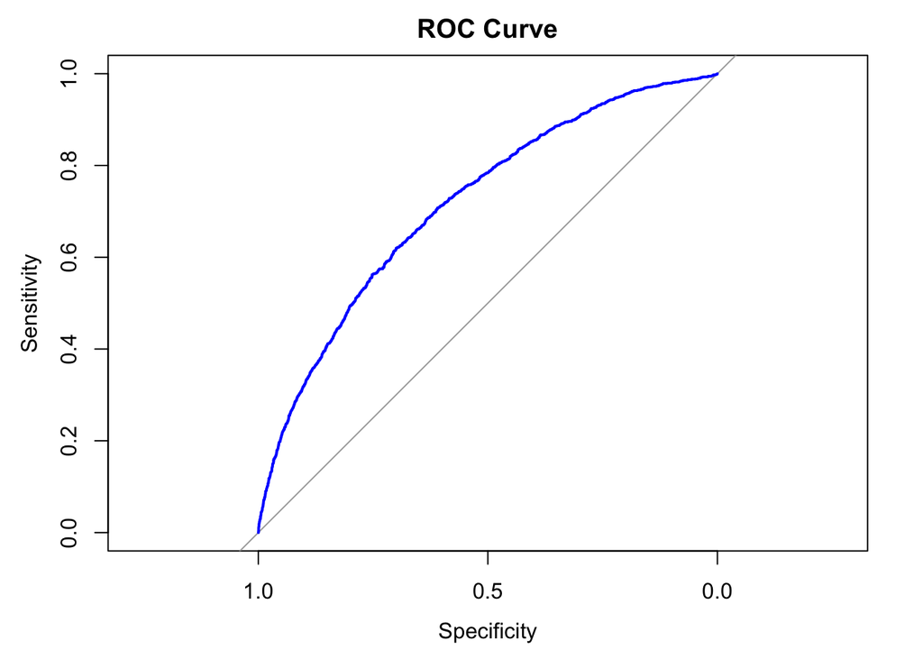

```r
# 获取预测概率
pred_probs <- predict(lm2_2, type = "response")

# 将预测结果转换为类别
pred_class <- ifelse(pred_probs > 0.5, 1, 0)  # 阈值为0.5，根据需要调整

roc_curve <- roc(data$CVD, pred_probs)
plot(roc_curve, main = "ROC Curve", col = "blue", lwd = 2)
```

```r
# 转换为 ggplot 对象
roc_ggplot <- ggroc(roc_curve)
# 保存为 PNG 文件
ggsave("../visulization/roc_curve_ggplot.png", plot = roc_ggplot, width = 8, height = 6)


auc(roc_curve)
```

```
## Area under the curve: 0.7165
```

输出95%置信区间

```r
# 计算模型参数的95%置信区间
confint <- confint(lm2_2, level = 0.95)
write.csv(confint, "../result/confint.csv")

print(confint)
```

```
##                        2.5 %        97.5 %
## (Intercept)     -8.696930440 -5.3142443889
## TyG_Index        0.184475111  0.5403953318
## Uric_Acid        0.109623109  0.1908897774
## Gender          -0.423062917 -0.1453388253
## Age              0.032991115  0.0507299447
## BMI              0.007067886  0.0286106251
## Triglycerides   -0.003050702 -0.0005066343
## LDL             -0.014462504 -0.0109554181
## HDL             -0.018829000 -0.0095105543
## Smoking_Status2  0.034439842  0.2932459160
## Smoking_Status3  0.225571100  0.6027199931
## Marital_Status2  0.159401990  0.4204222945
## Marital_Status3 -0.331579999  0.2884452084
## Race2           -0.010810775  0.5318223576
## Race3            0.228018077  0.6010305852
## Race4           -0.051388221  0.3986485148
## Race5           -0.195150255  0.3999085892
## BP_Meds2        -0.468013380  0.2102656311
## BP_Meds9        -1.106755485  4.5664964668
```

校准度分析

```r
# 生成预测概率
data$pred_prob <- predict(lm2_2, type = "response")

# Hosmer-Lemeshow检验
hl_test <- hoslem.test(lm2_2$y, data$pred_prob, g = 10)
print(hl_test)
```

```
##
##  Hosmer and Lemeshow goodness of fit (GOF) test
##
## data:  lm2_2$y, data$pred_prob
## X-squared = 5.8807, df = 8, p-value = 0.6606
```

校准度评估：

p值 = 0.66 远大于常见显著性水平（0.05）

结论：无法拒绝原假设，表明模型的预测概率与观测结果具有良好的一致性

实际意义：模型能够准确预测事件发生的概率（例如，当模型预测10%概率时，实际观测到的事件发生率也接近10%）

临床效用分析

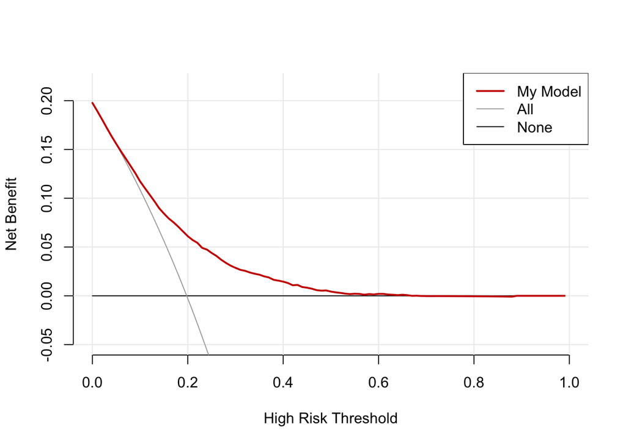

```r
# 决策曲线分析
dca_data <- decision_curve(CVD ~ pred_prob,
                          data = data,
                          policy = "opt-in",
                          fitted.risk = TRUE,
                          thresholds = seq(0, 1, by = 0.01))

# 绘制决策曲线
plot_decision_curve(dca_data,
                    curve.names = "My Model",
                    cost.benefit.axis = FALSE,
                    standardize = FALSE,
                    confidence.intervals = FALSE)
```

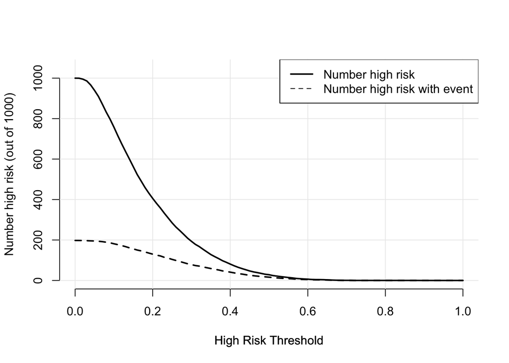

```r
# 临床影响曲线
plot_clinical_impact(dca_data,
                     population.size = 1000,
                     cost.benefit.axis = FALSE,
                     confidence.intervals = FALSE)
```

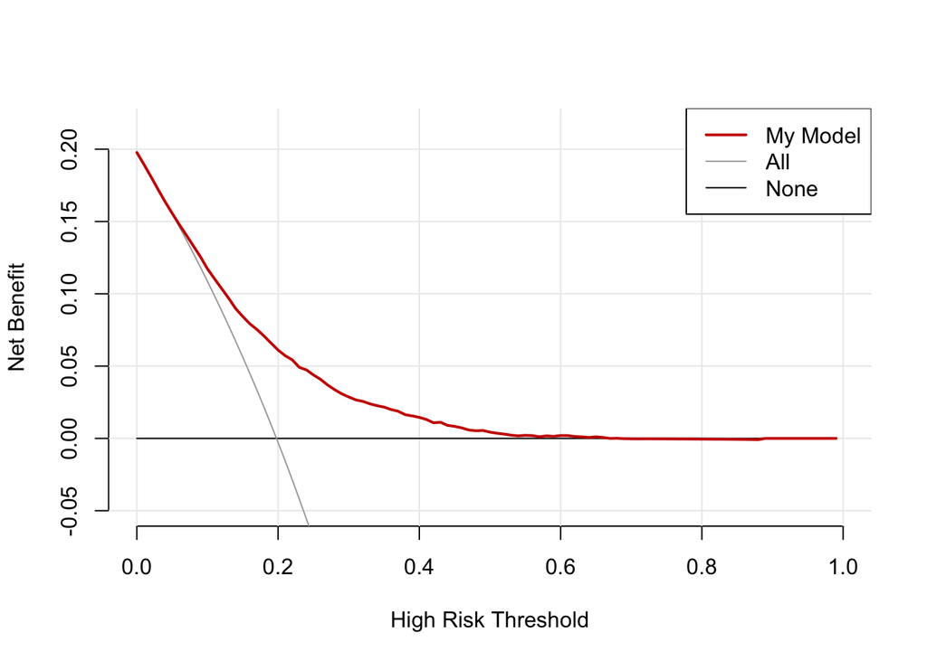

```r
ggsave("../visulization/Decision_Curve_ggplot.png",
       plot = plot_decision_curve(dca_data,
                    curve.names = "My Model",
                    cost.benefit.axis = FALSE,
                    standardize = FALSE,
                    confidence.intervals = FALSE), # 替换为完整参数
       width = 8, height = 6, dpi = 300)
```

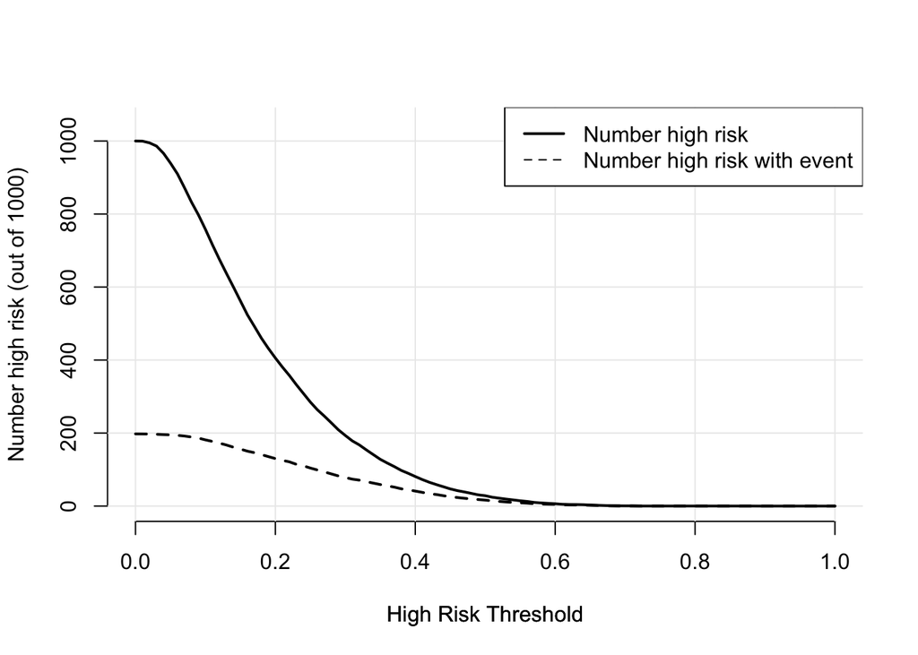

```r
ggsave("../visulization/clinical_impact.png",
       plot = plot_clinical_impact(dca_data,
                     population.size = 1000,
                     cost.benefit.axis = FALSE,
                     confidence.intervals = FALSE), # 替换为完整参数
       width = 8, height = 6, dpi = 300)
```